# Tutorial 7.2: Multiple regression on the fish tank dataset

As an exercise on multiple regression, we will analyse the fish tank dataset.

## 0.1 Fish tank dataset

In this experiments 96 fish (dojofish, goldfish and zebrafish) were placed separately in a tank with two liters of water and a certain dose (in mg) of a certain poison EI-43,064. The resistance of the fish a against the poison was measured as the amount of minutes the fish survived upon adding the poison (Surv_time, in minutes). Additionally, the weightt of each fish was measured.

## 0.2 Goal

In this tutorial, we will study the association between dose and survival time, while correcting for weight and species, by using a multiple regression model.

Read the required libraries

```r
library(readr)
library(dplyr)
library(tidyverse)
library(ggplot2)
library(car)
```

## 0.3 Import the data

```r
poison <- read_csv("poison.csv")
```

## 0.4 Data tidying

```r
head(poison)
```

```
## # A tibble: 6 x 4
##   species Weight  Dose Surv_time
##     <dbl>  <dbl> <dbl>     <dbl>
## 1       0   1.88   1        3.46
## 2       2   1.73   1.1      2.11
## 3       1   2.83   1.2     11.4
## 4       2   1.75   1.3      1.82
## 5       0   2.11   1.4      3.28
## 6       0   1.85   1.5      2.96
```

We can see a couple of things in the data that can be improved upon:

1. Capitalize the fist column name
2. Set the Species column as a factor
3. Change the speciec factor levels from 0, 1 and 2 to Dojofish, Goldfish and Zebrafish. Hint: use the fct_recode function.
4. Add the variable log.Surv_time: we already saw in previous tutorials that this transfromation is required to obtain normally distributed data.

```r
poison <- poison %>%
  rename("Species" = "species") %>%
  mutate(Species = as.factor(Species)) %>%
  mutate(Species = fct_recode(Species, Dojofish = "0", Goldfish = "1", Zebrafish = "2")) %>%
  mutate(log.Surv_time = log(Surv_time))

poison
```

```
## # A tibble: 96 x 5
##    Species   Weight  Dose Surv_time log.Surv_time
##    <fct>      <dbl> <dbl>     <dbl>         <dbl>
##  1 Dojofish    1.88   1        3.46         1.24
##  2 Zebrafish   1.73   1.1      2.11         0.747
##  3 Goldfish    2.83   1.2     11.4          2.44
##  4 Zebrafish   1.75   1.3      1.82         0.599
##  5 Dojofish    2.11   1.4      3.28         1.19
##  6 Dojofish    1.85   1.5      2.96         1.08
##  7 Zebrafish   1.22   1.6      1.85         0.615
##  8 Goldfish    2.05   1.7      8.05         2.09
##  9 Dojofish    1.80   1.8      1.65         0.504
## 10 Goldfish    2.50   1.9      7.95         2.07
## # … with 86 more rows
```

## 0.5 Data exploration

In a previous tutorial, we already studied the effect of dose on (the logarithm of) suvival time. There, we did not account for the fact that fish of the same species and/or fish of similar weight will probably reacht similarly to the poison.

When we expect the data more closely, we see that these factors do indeed matter.

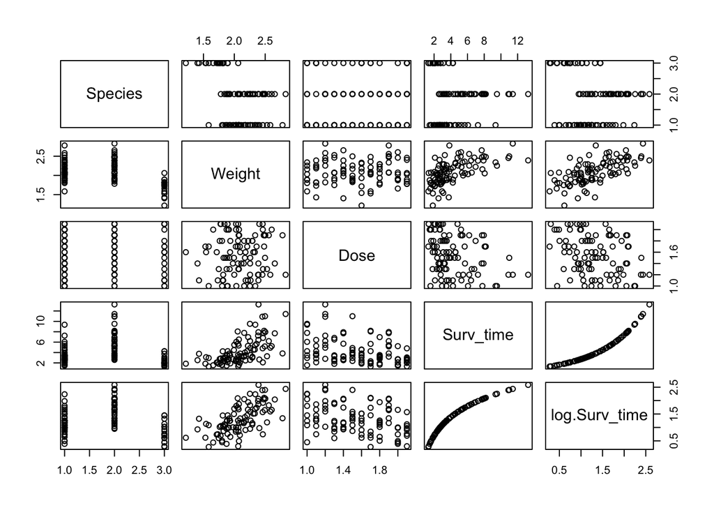

```r
plot(poison)
```

```r
library(GGally)
```

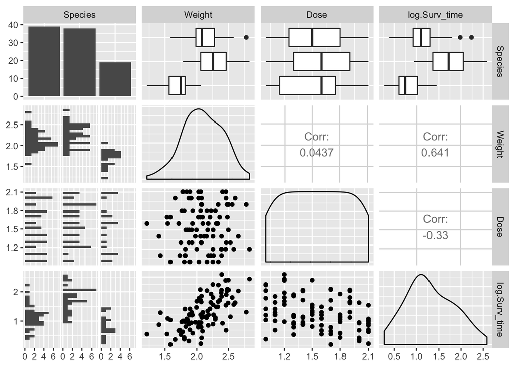

```r
poison %>% select(-Surv_time) %>% ggpairs()
```

Some additional visualizations:

- Plot the log survival time in function of weigth. Add species as a color.

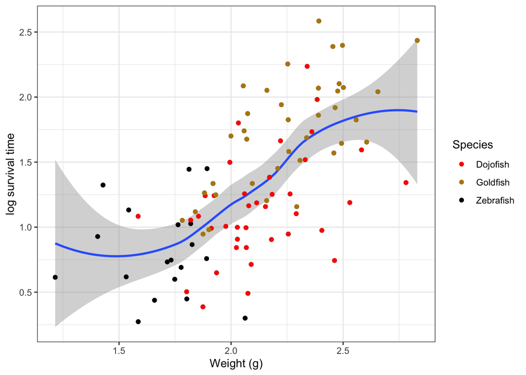

```r
poison %>%
  ggplot(aes(x=Weight,y=log.Surv_time)) +
  geom_point() +
  stat_smooth(method = "loess") +
  ylab("log survival time") +
  xlab("Weight (g)") +
  geom_point(aes(col=Species)) +
  scale_color_manual(values = c("red","darkgoldenrod","black")) +
  theme_bw()
```

- Plot the fish weights in function of dose

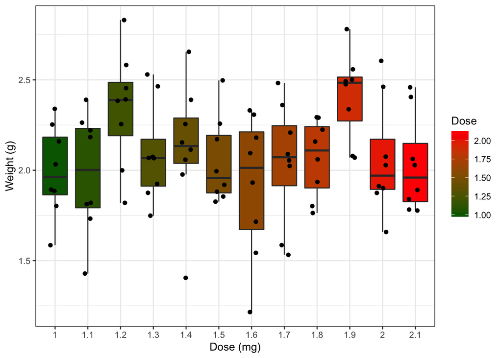

```r
poison %>%
  ggplot(aes(x=as.factor(Dose),y=Weight,fill=Dose)) +
  geom_boxplot(outlier.shape=NA) +
  geom_jitter(width = 0.2) +
  scale_fill_gradient(low = "darkgreen", high = "red") +
  ylab("Weight (g)") +
  xlab("Dose (mg)") +
  theme_bw()
```

We see that, probably by chance, some dosages were administered to fish with slightly higher (e.g. dose 1.9 mg) or lower weights.

- Plot the log of survival time in function of dose.

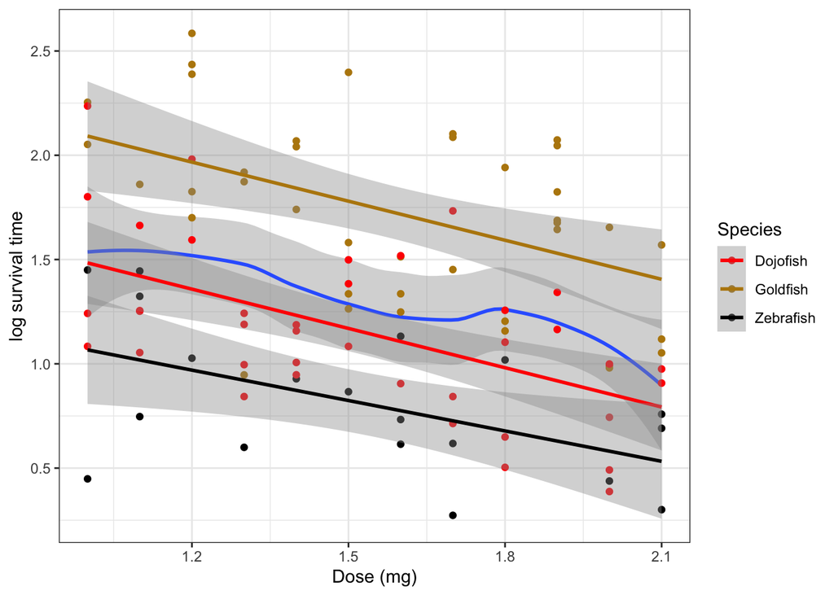

```r
poison %>%
  ggplot(aes(x=Dose,y=log.Surv_time)) +
  stat_smooth(method = "loess") +
  ylab("log survival time") +
  xlab("Dose (mg)") +
  geom_point(aes(col=Species)) +
  scale_color_manual(values = c("red","darkgoldenrod","black")) +
  theme_bw() +
  geom_smooth(aes(group=Species,col=Species), method='lm')
```

There is a clear linear relationship between dose and log survival time, but especially the intercept of the linear model will be different for different species.

- Plot the relationship between log survival time and species.

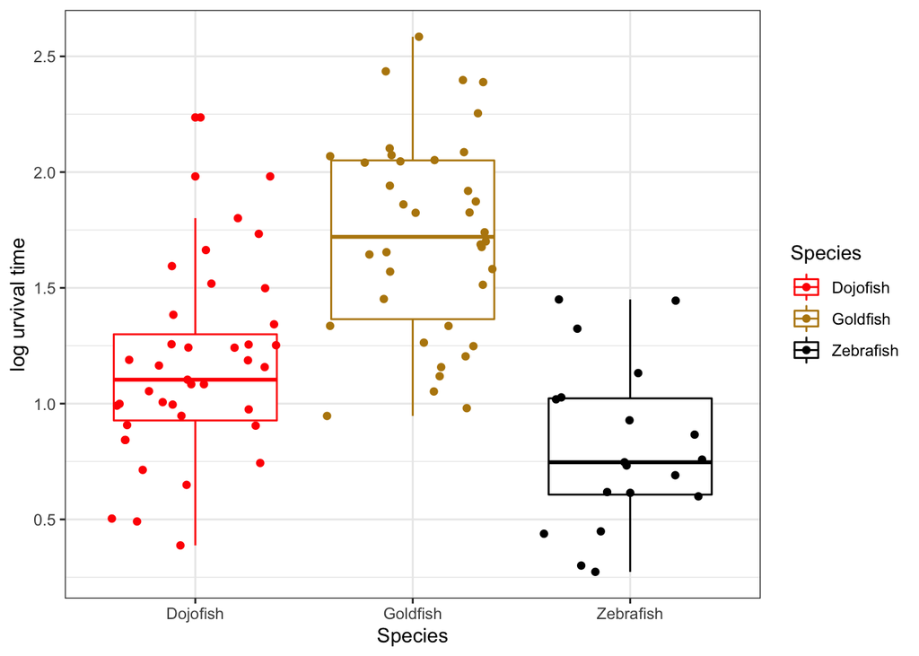

```r
poison %>%
  ggplot(aes(x=Species,y=log.Surv_time,color=Species)) +
  geom_boxplot() +
  geom_jitter() +
  ylab("log urvival time") +
  scale_color_manual(values = c("red","darkgoldenrod","black")) +
  theme_bw()
```

The log survival time is different for different species.

# 1 Generate model with main effects

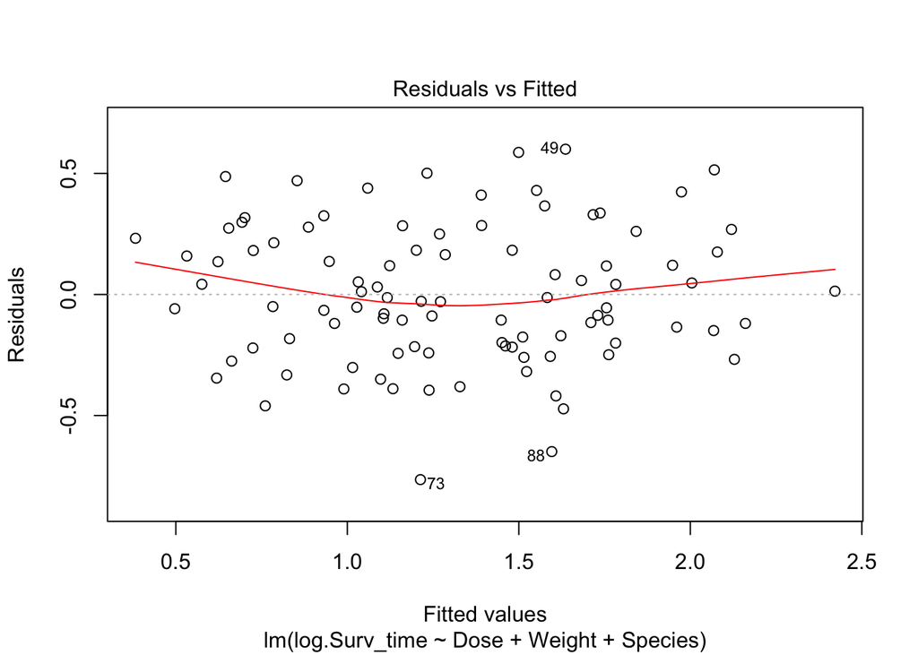

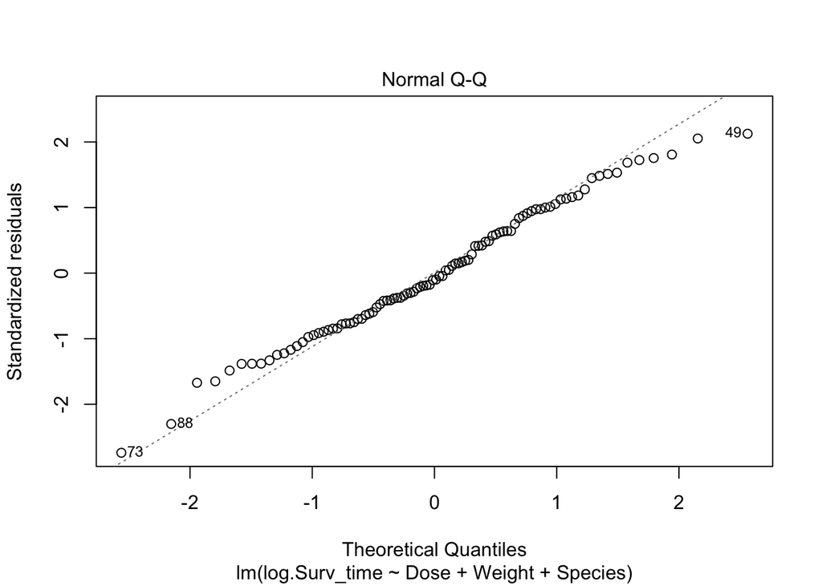

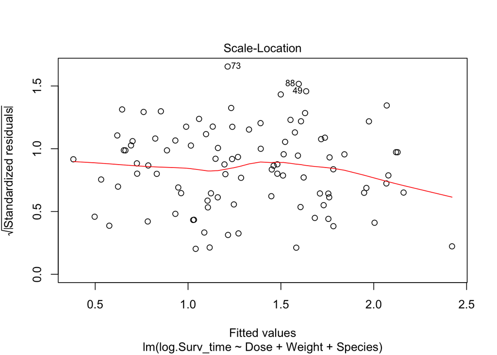

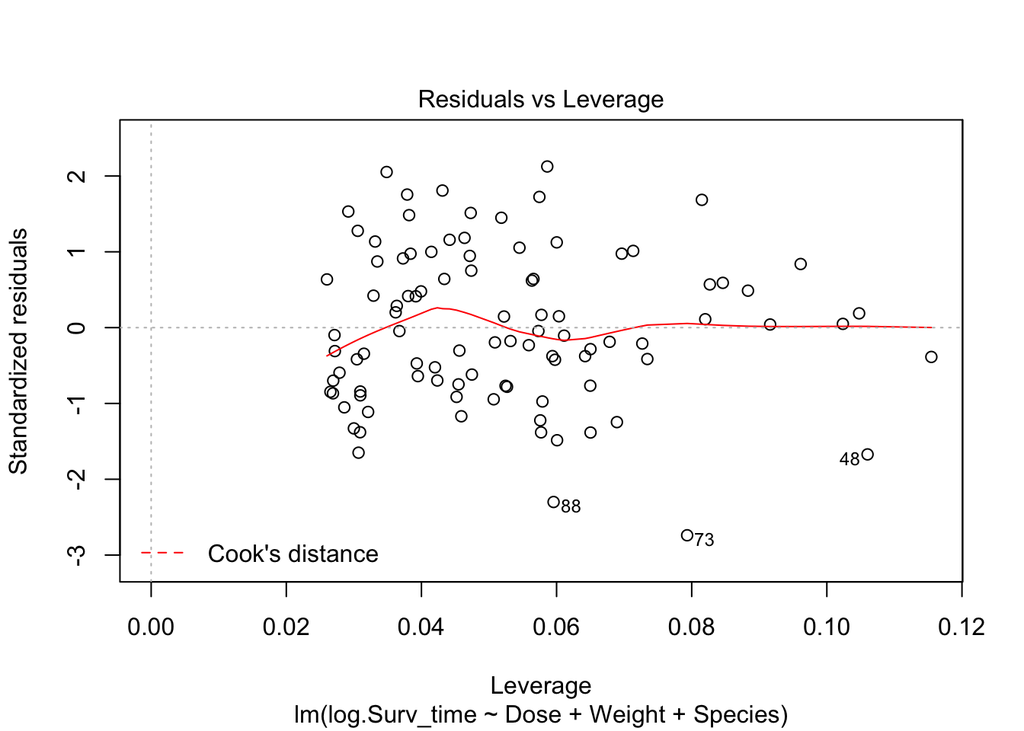

```r
lm_main <- lm(log.Surv_time~ Dose + Weight + Species, data=poison)

# to assess the assumptions:
plot(lm_main)
```

```r
Anova(lm_main)
```

```
## Anova Table (Type II tests)
##
## Response: log.Surv_time
##           Sum Sq Df F value    Pr(>F)
## Dose      4.1026  1  48.441 5.118e-10 ***
## Weight    3.4457  1  40.684 7.311e-09 ***
## Species   4.9579  2  29.269 1.531e-10 ***
## Residuals 7.7071 91
## ---
## Signif. codes:  0 '***' 0.001 '**' 0.01 '*' 0.05 '.' 0.1 ' ' 1
```

```r
summary(lm_main)
```

```
##
## Call:
## lm(formula = log.Surv_time ~ Dose + Weight + Species, data = poison)
##
## Residuals:
##      Min       1Q   Median       3Q      Max
## -0.76480 -0.21341 -0.02902  0.21811  0.60013
##
## Coefficients:
##                   Estimate Std. Error t value Pr(>|t|)
## (Intercept)       0.363354   0.300467   1.209    0.230
## Dose             -0.600836   0.086328  -6.960 5.12e-10 ***
## Weight            0.800833   0.125554   6.378 7.31e-09 ***
## SpeciesGoldfish   0.512218   0.068207   7.510 3.92e-11 ***
## SpeciesZebrafish  0.007252   0.098114   0.074    0.941
## ---
## Signif. codes:  0 '***' 0.001 '**' 0.01 '*' 0.05 '.' 0.1 ' ' 1
##
## Residual standard error: 0.291 on 91 degrees of freedom
## Multiple R-squared:  0.7195, Adjusted R-squared:  0.7072
## F-statistic: 58.37 on 4 and 91 DF,  p-value: < 2.2e-16
```

Interpret the model parameters: